# I’m Going to Miss My Flight!

An analysis of flight delay times across airports

Natalie LePera

West Chester University | STA552 - HW 01

05 Feb 2025

# 1 Introduction

Air travel has become a pivotal feature of the ever globalized world, driving global trade, connecting individuals and countries alike, and driving global economic growth. According to the [Air Transport Action Group](https://atag.org/facts-figures) in 2023, a total of 35.3 million flights carried a total of **4.4 billion passengers** and **61.4 million tonnes of cargo** between 4,072 global airports. This resulted in a $4.1 trillion total global economic contribution in 2023 alone. While only 1% of all global trade is conducted through air travel, air shipping accounts for 33% of all trade value, indicating that the most expensive goods are shipped via air travel.

Due to the massive impact of air travel on our global communities and GDPs, there has been significant efforts implemented to streamline air travel and reduce fight delays to ensure smooth predictable travel. Mitigation and reduction of overall air travel delays will allow for increased air travel driven trade output and overall boosts to the global economy. In order to properly mitigate air travel delays, confounding factors that may impact flight delays were captured by Deepti Gupta in Applied Analytics through Case Studies Using SAS and R for analysis and modeling.

## 1.1 Data Details

Flight delay data as collected from *Applied Analytics through Case Studies Using SAS and R, Deepti Gupta by APress, ISBN - 978-1-4842-3525-6* was downloaded from https://pengdsci.github.io/datasets/.

| Variable Name | Variable Type | Details |
| --- | --- | --- |
| Carrier | Categorical | Airline (Carrier) |
| Airport Distance | Numeric | Distance (miles) between departure and arrival airport |
| Number of Flights | Numeric | Total number of flights at arrival airport |
| Weather | Numeric | A ranking of delays due to weather condition (0: Mild to 10: Extreme) |
| Suport Crew | Numeric | Total number of support crew available |
| Baggage Loading Time | Numeric [Binned] | Total time for baggage loading (minutes) |
| Late Plane Arrival | Numeric | Delay time for plane arrival prior to flight (minutes) |
| Cleaning | Numeric [Binned] | Time required to clean plane after arrival prior to passenger loading (minutes) |
| Fueling | Numeric | Time required to fuel aircraft (minutes) |
| Secutiry | Numeric | Time required for security checks (minutes) |
| Arrival Delay | Numeric | Total flight delay time (minutes) |

```r
delay <- read.csv("https://nlepera.github.io/sta552/HW01/data/Flight_delay-data.csv")
```

## 1.2 Analysis Goals

Through analyzing this flight data I set out to determine the factors with the greatest impact on overall flight delays. Through identifying the factors with greatest impact on flight arrival delays this information can then be leveraged by airports and airlines to improve staffing, streamline pre-flight processes, and ultimately mitigate delays due to factors within the airlines’ or airports’ control.

# 2 Exploratory Data Analysis

Prior to any data analysis and visualization, the airline delay data was cleaned and modified to meet the requirements of the assignment. To properly analyze the data, two numeric variables were binned to create categorical values (baggage loading time & cleaning time). Additionally, outliers and impossible values were identified and removed.

## 2.1 Outlier Removal

```r
impossible <- delay %>% filter(Cleaning_o < 0) %>% select(c(Carrier, Cleaning_o, Arr_Delay))

pander::pander(impossible, caption = "Summary of Impossible Cleaning Time Observations")
```

Summary of Impossible Cleaning Time Observations

| Carrier | Cleaning_o | Arr_Delay |
| --- | --- | --- |
| B6 | -1 | 70 |
| EV | -4 | 82 |
| WN | -1 | 75 |
| EV | -1 | 54 |
| B6 | -1 | 88 |

```r
delay.clean <- delay %>%
  mutate(Cleaning_o = replace(Cleaning_o, Cleaning_o < 0, "NA"))

delay.clean$Cleaning_o <- as.numeric(delay.clean$Cleaning_o)

pander::pander(summary(delay.clean$Cleaning_o), caption = "Summary of Cleaning Time After Missing Value Removal")
```

Summary of Cleaning Time After Missing Value Removal

| Min. | 1st Qu. | Median | Mean | 3rd Qu. | Max. | NA’s |
| --- | --- | --- | --- | --- | --- | --- |
| 0 | 8 | 10 | 10.04 | 12 | 23 | 5 |

## 2.2 Binning

```r
bin_clean <- c(0, 6, 12, 18, 23)
labels_clean <- c("Immediate", "Quick", "Moderate", "Slow")

delay.clean <- delay.clean %>%
  mutate(Cleaning_o = cut(Cleaning_o, breaks = bin_clean, labels = labels_clean, right = TRUE, include.lowest = TRUE))

bin_baggage <- c(14, 16, 18, 19)
labels_baggage <- c("Fast", "Moderate", "Slow")

delay.clean <- delay.clean %>%
  mutate(Baggage_loading_time = cut(Baggage_loading_time, breaks = bin_baggage, labels = labels_baggage, right = TRUE, include.lowest = TRUE))

binned_columns <- delay.clean %>%
  select(c(Cleaning_o, Baggage_loading_time))

pander::pander(summary(binned_columns), caption = "Binned Variables Summary")
```

Binned Variables Summary

| Cleaning_o | Baggage_loading_time |
| --- | --- |
| Immediate: 517 | Fast : 749 |
| Quick :2261 | Moderate:2833 |
| Moderate : 780 | Slow : 11 |
| Slow : 30 | NA |
| NA’s : 5 | NA |

## 2.3 Forced Missing Values

For the purposes of this exercise missing values were artificially created per the assignment instructions. Missing values were forced for weather, support crew, and late inital plane arrival time; a summary table below indicating the total number of missing values is included for ease of reference.

```r
weather.missing <- sample(1:3593, 5, replace = FALSE)
late.missing <- sample(1:3593, 6, replace = FALSE)
support.missing <- sample(1:3593, 4, replace = FALSE)
delay.clean$Weather[weather.missing] <- NA
delay.clean$Late_Arrival_o[late.missing] <- NA
delay.clean$Support_Crew_Available[support.missing] <- NA

kable(sapply(delay.clean, function (x) sum(is.na(x))), caption = "Count of Blank Values", col.names = c("Variables", "Count of Blank Values")) %>%
  kable_styling()
```

Count of Blank Values

| Variables | Count of Blank Values |
| --- | --- |
| Carrier | 0 |
| Airport_Distance | 0 |
| Number_of_flights | 0 |
| Weather | 5 |
| Support_Crew_Available | 4 |
| Baggage_loading_time | 0 |
| Late_Arrival_o | 6 |
| Cleaning_o | 5 |
| Fueling_o | 0 |
| Security_o | 0 |
| Arr_Delay | 0 |

# 3 Variable Relationship Exploration

## 3.1 Binned Data Comparrison

With this information, airlines and airports can prioritize baggage handler staffing over cleaning team staffing to improve flight delay times with minimal change to ground procedures. Shaving 1 to 2 minutes of baggage loading time can in turn reduce flight delays significantly.

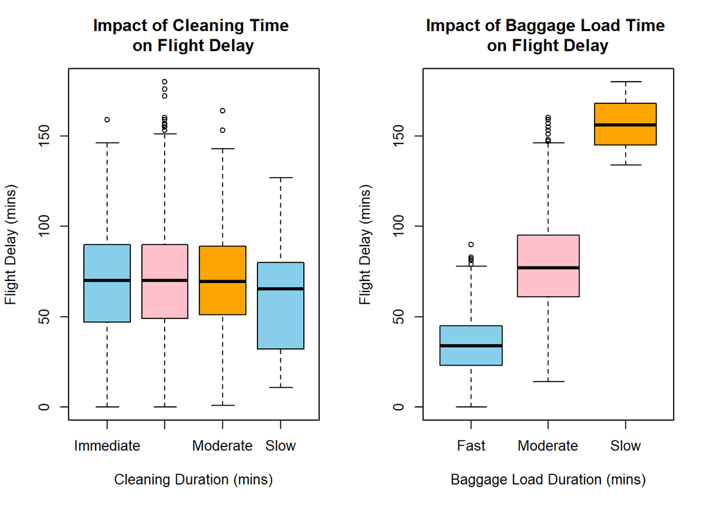

```r
par(mfrow = c(1,2))
layout <- layout(matrix(c(1,1,2,2), 2, 2, byrow = FALSE))
boxplot(delay.clean$Arr_Delay ~ delay.clean$Cleaning_o,
                               xlab = "Cleaning Duration (mins)",
                               ylab = "Flight Delay (mins)",
                               col = c("skyblue", "pink", "orange"),
                               main = "Impact of Cleaning Time
on Flight Delay")

boxplot(delay.clean$Arr_Delay ~ delay.clean$Baggage_loading_time,
                               xlab = "Baggage Load Duration (mins)",
                               ylab = "Flight Delay (mins)",
                               col = c("skyblue", "pink", "orange", "purple"),
                               main = "Impact of Baggage Load Time
on Flight Delay")
```

## 3.2 Staffing Needs Analysis

Diving further into the staffing needs, overall number of available support staff compared to flight delays was investigated, controlling for baggage loading speed. A clear pattern emerges illustrating that the greater number of support staff available, a greater bag loading speed is seen, and thus a reduction in flight delays is also seen. This trend again illustrates the importance of proper airport staffing overall to reduce flight delays.

```r
plot_ly(data = delay.clean, x = ~Support_Crew_Available, y = ~Arr_Delay,
                     color = ~Baggage_loading_time, colors = c("skyblue", "pink", "orange"),
                     marker = list(size= ~Arr_Delay/15)) %>%
  layout(title = "Correlation Between Support Crews & Flight Delays",
         xaxis = list(title = "Total Support Staff Available"),
         ylab = list(title = "Total Flight Delay (mins)"))
```

[interactive chart not shown]

An overall pairwise comparison of flight delays compared to late incoming plane arrivals, fueling time, and security check duration was completed controlling for both the overall baggage loading time to examine for further compounding factors relating to overall flight delays.

```r
delay.clean.plot <- delay.clean

names(delay.clean.plot) = c("Carrier", "Airport_Distance", "Flight_Totals", "Weather", "Support", "Baggage", "Late_Plane", "Cleaning", "Fueling", "Security", "Flight_Delay")

pairwise.bags <- ggpairs(delay.clean.plot, columns = c(7, 9:11), aes(color = factor(Baggage), alpha= 0.4),
        upper = list(continous = wrap("cor"), size = 3),
             margin = list(l = 50, r = 50, b = 50, t = 50, pad = 20)) +
  ggtitle("Pairwise Comparrison of Plane Delays - Baggage Loading") +
  theme (
    plot.title = element_text(hjust = 1),
    plot.margin = unit(c(1, 2, 2, 1), "cm"))

ggplotly(pairwise.bags)
```

[interactive chart not shown]

```r
par(mfrow = c(1,2))
layout <- layout(matrix(c(1,1,2,2), 2, 2, byrow = FALSE))
plot_ly(data = delay.clean, x = ~Late_Arrival_o, y = ~Arr_Delay,
                     color = ~Baggage_loading_time, colors = c("skyblue", "pink", "orange"),
                     marker = list(size= ~Arr_Delay/15)) %>%
  layout(title = "Correlation Between Incoming Plane Delay & Flight Delays",
         xaxis = list(title = "Incoming Plane Delay Time (mins)"),
         yaxis = list(title = "Total Flight Delay (mins)"))
```

[interactive chart not shown]

```r
plot_ly(data = delay.clean, x = ~Support_Crew_Available, y = ~Late_Arrival_o,
                     color = ~Baggage_loading_time, colors = c("skyblue", "pink", "orange"),
                     marker = list(size= ~Arr_Delay/15)) %>%
  layout(title = "Correlation Between Available Support Crew & Incoming Plane Delays",
         xaxis = list(title = "Available Support Crews"),
         yaxis = list(title = "Incoming Plane Delays (mins)"))
```

[interactive chart not shown]

# 4 Conclusions

Overall it has been demonstrated that in order to reduce flight delays, the primary point of focus should be proper airline and airport staffing. With razor thin margins on baggage loading time, extra planning and staffing should be focused around ensuring rapid baggage loading into outgoing flights. A secondary focus must be placed on ensuring incoming plane delays are mitigated to prevent downstream backup, and reduce flight delays overall. Proper staffing and reduction in delays will lead to increased airline profits, increased customer satisfaction, and overall increased consistency and adherence to flight schedules. Improved adherence to flight schedules will also result in reduction of potential aviation fines for both the airlines and all serviced airports.

# 5 References

Data Source: Applied Analytics through Case Studies Using SAS and R, Deepti Gupta by APress, ISBN - 978-1-4842-3525-6

Air travel: https://atag.org/facts-figures